# Exercises for chapter 9

Author

Winnie

Published

April 15, 2024

# Clarification and or discussion questions

What did 9M2 want us to reflect on (when changing beta from normal distribution to exponential)?

Guido: this hard constraint is a problem, as our data do include datapoints for non-african countries where the beta is negative(?). It would better to have a softer constraint: normal distribution further up the positive side with thin tails to the negative side.

# Easy.

## 9E1. Metropolis requirement

**Which of the following is a requirement of the simple Metropolis algorithm?**

(1) The parameters must be discrete.

(2) The likelihood function must be Gaussian. <- Yes?

(3) The proposal distribution must be symmetric. <- Yes.

## 9E2. Gibbs efficiency

**Gibbs sampling is more efficient than the Metropolis algorithm. How does it achieve this extra efficiency? Are there any limitations to the Gibbs sampling strategy?**

Gibbs sampling is less random.

Straight from the book, because I do not really understand the mechanics behind it: The improvement arises from adaptive proposals in which the distribution of proposed parameter values adjusts itself intelligently, depending upon the parameter values at the moment. How Gibbs sampling computes these adaptive proposals depends upon using particular combinations of prior distributions and likelihoods known as conjugate pairs. Conjugate pairs have analytical solutions for the posterior distribution of an individual parameter. And these solutions are what allow Gibbs sampling to make smart jumps around the joint posterior distribution of all parameters.

## 9E3. Which sort of parameters can Hamiltonian Monte Carlo not handle? Can you explain why?

Cannot handle discrete parameters as the estimation is smooth and needs the possibility to stop at any time.

## 9E4. n_eff vs actual #samples

**Explain the difference between the effective number of samples, n_eff as calculated by Stan, and the actual number of samples.**

The effective number of samples is the required number of samples to achieve the same posterior distribution that was found from the actual number of samples but given an autocorrelated sampling pattern. The actual number of samples is autocorrelated, which means the samples are dependent on each other.

## 9E5. Rhat, approach what?

**Which value should Rhat approach, when a chain is sampling the posterior distribution correctly?** Not sure, but all of the Rhat for the estimated parameters are set as 1 in the precis(model.x)-table.

From the book:

When Rhat is above 1.00, it usually indicates that the chain has not yet converged, and probably you shouldn’t trust the samples. Rhat can reach 1.00 even for an invalid chain. So view it perhaps as a signal of danger, but never of safety.

## 9E6. Trace and trank plot

**Sketch a good trace plot for a Markov chain, one that is effectively sampling from the posterior distribution. What is good about its shape? Then sketch a trace plot for a malfunctioning Markov chain. What about its shape indicates malfunction?**

Building upon the example from the book.

```r
library(rethinking)
data(rugged)
d <- rugged %>%
  filter(!is.na(rgdppc_2000)) %>%
 mutate(log_gdp = log(rgdppc_2000),
        log_gdp_std = log_gdp / mean(log_gdp),
        rugged_std = rugged / max(rugged),
        cid = ifelse( cont_africa==1 , 1 , 2 )
        )


dat_slim <- list(
  log_gdp_std = d$log_gdp_std,
  rugged_std = d$rugged_std,
  cid = as.integer( d$cid )
  )

str(dat_slim)
```

```
List of 3
 $ log_gdp_std: num [1:170] 0.88 0.965 1.166 1.104 0.915 ...
 $ rugged_std : num [1:170] 0.138 0.553 0.124 0.125 0.433 ...
 $ cid        : int [1:170] 1 2 2 2 2 2 2 2 2 1 ...
```

```r
m9.1 <- map2stan(
  alist(
    log_gdp_std ~ dnorm( mu , sigma ) ,
    mu <- a[cid] + b[cid]*( rugged_std - 0.215 ) ,
    a[cid] ~ dnorm( 1 , 0.1 ) ,
    b[cid] ~ dnorm( 0 , 0.3 ) ,
    sigma ~ dexp( 1 )
    ),
  data=dat_slim , chains=4 , cores=4 , iter=1000
  )
```

```
Computing WAIC
```

```r
#Keep getting warnings when using traceplot() or trankplot() on ulam-object.
# m9.1 <- ulam(
#   alist(
#     log_gdp_std ~ normal( mu , sigma ) ,
#     mu <- a[cid] + b[cid]*( rugged_std - 0.215 ) ,
#     a[cid] ~ normal( 1 , 0.1 ) ,
#     b[cid] ~ normal( 0 , 0.3 ) ,
#     sigma ~ exponential( 1 )
#     ),
#   data=dat_slim , chains=4 , cores=4 , iter=1000
#   )
```

Below traceplot and trankplot has been plotted for the estimation process of model 9.1 (a model that take into account ruggedness and yes-no if the country is in Africa.) The chains look healthy by the three qualities: (1) stationarity, (2) good mixing, and (3) convergence.

The first few samples of the parameters chain show great mixing as the intervals start out wide, stretching the trace plots and dwarfing the successive samples. But after the wide search, the chain seem to convergence to a stationary interval. The trankplot show good mixing between the chains (= not long stretches at the same y-value).

Traceplot:

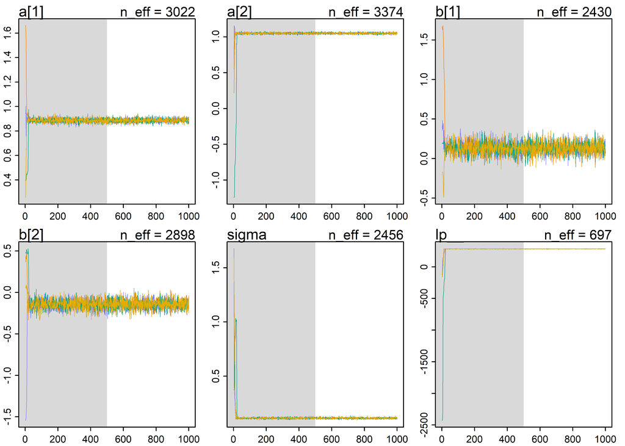

```r
par(mfrow=c(1,1))

tracerplot(object= m9.1) # I could not make traceplot() work.
```

Trankplot:

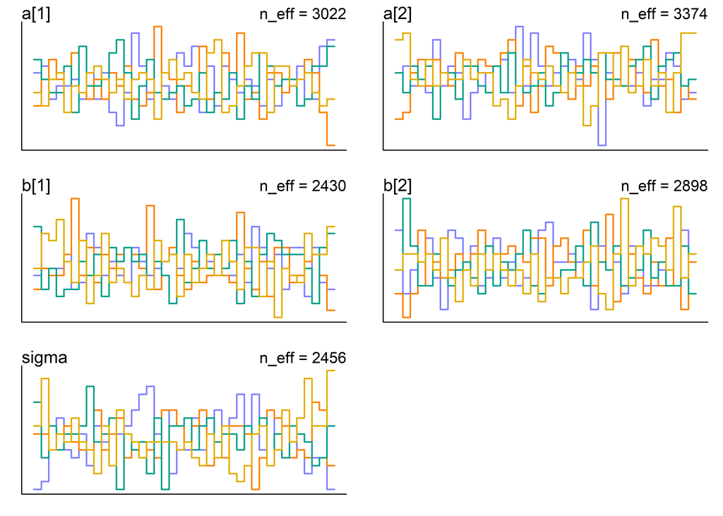

```r
#trankplot

trankplot( m9.1 , n_cols=2 )
```

# Medium.

## 9M1. Sigma ~ unif vs ~exp

**Re-estimate the terrain ruggedness model from the chapter, but now using a uniform prior and an exponential prior for the standard deviation, sigma. The uniform prior should be dunif(0,10) and the exponential should be dexp(1). Do the different priors have any detectible influence on the posterior distribution?**

An exercise to show a soft constraint. But this time we had so much data that the influence of priors did not really matter. M2 show that the case of hard constraints.

```r
m9.1_uni <- map2stan(
  alist(
    log_gdp_std ~ dnorm( mu , sigma ) ,
    mu <- a[cid] + b[cid]*( rugged_std - 0.215 ) ,
    a[cid] ~ dnorm( 1 , 0.1 ) ,
    b[cid] ~ dnorm( 0 , 0.3 ) ,
    sigma ~ dunif(0,10)
    ),
  data=dat_slim , chains=4 , cores=4 , iter=1000
  )
```

```
Computing WAIC
```

```r
# Have already estimated m9.1 in exercise 9E6.
# m9.1 <- map2stan(
#   alist(
#     log_gdp_std ~ dnorm( mu , sigma ) ,
#     mu <- a[cid] + b[cid]*( rugged_std - 0.215 ) ,
#     a[cid] ~ dnorm( 1 , 0.1 ) ,
#     b[cid] ~ dnorm( 0 , 0.3 ) ,
#     sigma ~ dexp( 1 )
#     ),
#   data=dat_slim , chains=4 , cores=4 , iter=1000
#   )


# oh, forgot to use post-estimates for anything...
# post9.1 <- extract.samples(m9.1)
# post9.1_uni <- extract.samples(m9.1)
```

Check m9.1. Yes, n_eff > iterations, and Rhat is 1.

```r
precis(m9.1, depth = 2)
```

```
            mean         sd       5.5%       94.5%    n_eff     Rhat4
a[1]   0.8868604 0.01565287  0.8621690  0.91198487 3022.078 0.9995572
a[2]   1.0506837 0.01048681  1.0337509  1.06825655 3374.279 0.9991476
b[1]   0.1332540 0.07518087  0.0119076  0.25485577 2430.233 0.9990864
b[2]  -0.1423280 0.05672139 -0.2342614 -0.05136212 2898.270 0.9988832
sigma  0.1114884 0.00621635  0.1020806  0.12178478 2456.280 0.9997799
```

Check m9.1_uni. Yes, it seem all good as well. n_eff > iterations, and Rhat is 1.

```r
precis(m9.1_uni, depth = 2)
```

```
            mean          sd        5.5%      94.5%    n_eff     Rhat4
a[1]   0.8857520 0.015848684  0.86051691  0.9108258 2589.264 1.0000297
a[2]   1.0506118 0.010455736  1.03420358  1.0673810 2819.691 1.0005622
b[1]   0.1359559 0.076673657  0.01774625  0.2547850 2233.968 0.9988014
b[2]  -0.1432702 0.054187406 -0.22870230 -0.0562703 3031.115 1.0008145
sigma  0.1116693 0.006131616  0.10235628  0.1216199 2584.115 0.9992816
```

Posterior distribution:

```r
mu9.1 <- link( m9.1 )
```

```
[ 100 / 1000 ]
[ 200 / 1000 ]
[ 300 / 1000 ]
[ 400 / 1000 ]
[ 500 / 1000 ]
[ 600 / 1000 ]
[ 700 / 1000 ]
[ 800 / 1000 ]
[ 900 / 1000 ]
[ 1000 / 1000 ]
```

```r
mu_mean9.1 <- apply( mu9.1 , 2 , mean )
mu_PI9.1 <- apply( mu9.1 , 2 , PI )

mu9.1_uni <- link( m9.1_uni )
```

```
[ 100 / 1000 ]
[ 200 / 1000 ]
[ 300 / 1000 ]
[ 400 / 1000 ]
[ 500 / 1000 ]
[ 600 / 1000 ]
[ 700 / 1000 ]
[ 800 / 1000 ]
[ 900 / 1000 ]
[ 1000 / 1000 ]
```

```r
# summarize samples across cases
mu_mean9.1_uni <- apply( mu9.1_uni , 2 , mean )
mu_PI9.1_uni <- apply( mu9.1_uni , 2 , PI )
```

Plotting the posteriors for the sigma-uni model and the sigma-exp model. They are almost identical. First they were plotted in the same plot area (diagram) and they were overlapping so well that the other color was completely hidden.

Does this mean that having the prior distribution for sigma ~ dexp(1) is actually just as uninformative as having a uniform distribution.

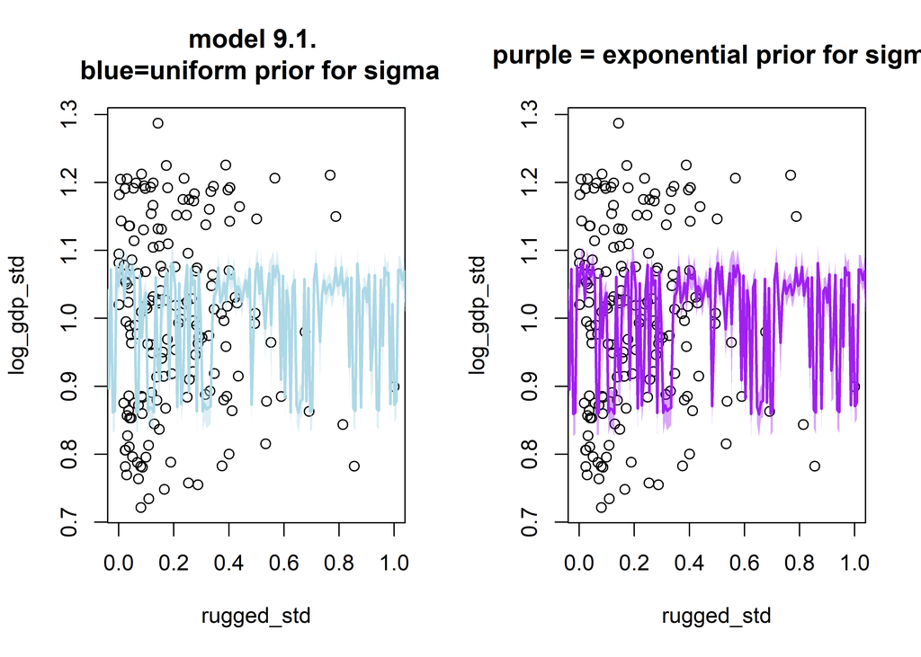

```r
# par(mfrow=c(1,1))
par(mfrow = c(1,2))

rugged_seq <- seq( from=-0.1 , to=1.1 , length.out=170 ) #0 to 1

plot( log_gdp_std ~ rugged_std , data=d ) #scatterplot
lines( rugged_seq , mu_mean9.1 , lwd=2 , col =  alpha("lightblue", 1))
shade( mu_PI9.1 , rugged_seq , col =  alpha("lightblue", 0.4))
title(main = "model 9.1. \n blue=uniform prior for sigma")

plot( log_gdp_std ~ rugged_std , data=d ) #scatterplot
lines( rugged_seq , mu_mean9.1_uni , lwd=2 , col =  alpha("purple", 1))
shade( mu_PI9.1_uni , rugged_seq , col =  alpha("purple", 0.4))
title(main = "purple = exponential prior for sigma")
```

```r
# scatter plot by  color for dummy variable 0/1 går ikke, men id 1/2 går.
# plot( log_gdp_std ~ rugged_std , data=d, col = cid)
```

## 9M2. Modify to b[cid]~dexp(0.3)

**Modify the terrain ruggedness model again. This time, change the prior for b[cid] to dexp(0.3). What does this do to the posterior distribution? Can you explain it?**

```r
m9.2 <- map2stan(
  alist(
    log_gdp_std ~ dnorm( mu , sigma ) ,
    mu <- a[cid] + b[cid]*( rugged_std - 0.215 ) ,
    a[cid] ~ dnorm( 1 , 0.1 ) ,
    b[cid] ~ dexp( 0.3 ) ,  # old: b[cid] ~ dnorm( 0 , 0.3 )
    sigma ~ dexp( 1 )
    ),
  data=dat_slim , chains=4 , cores=4 , iter=1000
  )
```

```
Computing WAIC
```

```r
mu9.2 <- link( m9.2 )
```

```
[ 100 / 1000 ]
[ 200 / 1000 ]
[ 300 / 1000 ]
[ 400 / 1000 ]
[ 500 / 1000 ]
[ 600 / 1000 ]
[ 700 / 1000 ]
[ 800 / 1000 ]
[ 900 / 1000 ]
[ 1000 / 1000 ]
```

```r
mu_mean9.2 <- apply( mu9.2 , 2 , mean )
mu_PI9.2 <- apply( mu9.2 , 2 , PI )
```

Well, it was not too easy to visually interpret any difference between the models by looking at the posterior distribution of log_gdp.

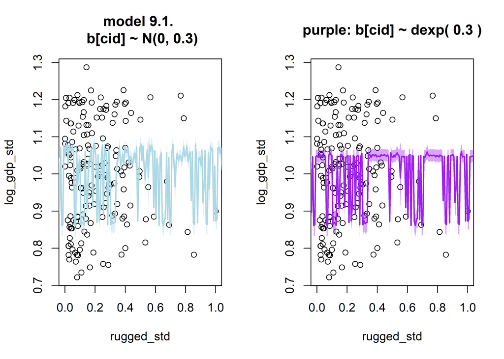

```r
par(mfrow = c(1,2))

rugged_seq <- seq( from=-0.1 , to=1.1 , length.out=170 ) #0 to 1

plot( log_gdp_std ~ rugged_std , data=d ) #scatterplot
lines( rugged_seq , mu_mean9.1 , lwd=2 , col =  alpha("lightblue", 1))
shade( mu_PI9.1 , rugged_seq , col =  alpha("lightblue", 0.4))
title(main = "model 9.1. \n b[cid] ~ N(0, 0.3)")

plot( log_gdp_std ~ rugged_std , data=d ) #scatterplot
lines( rugged_seq , mu_mean9.2 , lwd=2 , col =  alpha("purple", 1))
shade( mu_PI9.2 , rugged_seq , col =  alpha("purple", 0.4))
title(main = "purple: b[cid] ~ dexp( 0.3 )")
```

```r
# scatter plot by  color for dummy variable 0/1 går ikke, men id 1/2 går.
# plot( log_gdp_std ~ rugged_std , data=d, col = cid)
```

Looking at the WAIC m9.1 is a better model than m9.2??

```r
compare(m9.1, m9.2)
```

```
          WAIC       SE    dWAIC      dSE    pWAIC     weight
m9.1 -259.1314 14.64024 0.000000       NA 5.034426 0.93917401
m9.2 -253.6574 14.59117 5.473967 7.130747 3.349918 0.06082599
```

Sample the estimated betas for each model.

```r
# africa: cid =1, non-africa: cid =2

post9.1_b <- extract.samples(m9.1)$b %>%
  as.tibble() %>%
  setNames(c("africa", "non_africa")) %>%
  mutate(model = "m9.1") %>%
  pivot_longer(!model, values_to = "b", names_to = "continent")
post9.2_b <- extract.samples(m9.2)$b %>%
  as.tibble() %>%
  setNames(c("africa", "non_africa")) %>%
  mutate(model = "m9.2")%>%
  pivot_longer(!model, values_to = "b", names_to = "continent")

post_b <- post9.1_b %>%
  bind_rows(post9.2_b)
```

The beta is the difference between the models m9.1 (b~dnorm) and m9.2 (b~dexp). The betas have in common that they are estimated for each group: african country vs non-african country. Well, for the african countries they have almost identical betas in both models, but for non-african countries they look completely different. Not sure if I like the exponential distribution here.

Guido: this hard constraint is a problem, as our data do include datapoints for non-african countries where the beta is negative(?). It would better to have a softer constraint: normal distribution further up the positive side with thin tails to the negative side.

```
Warning: Using `size` aesthetic for lines was deprecated in ggplot2 3.4.0.
ℹ Please use `linewidth` instead.
```

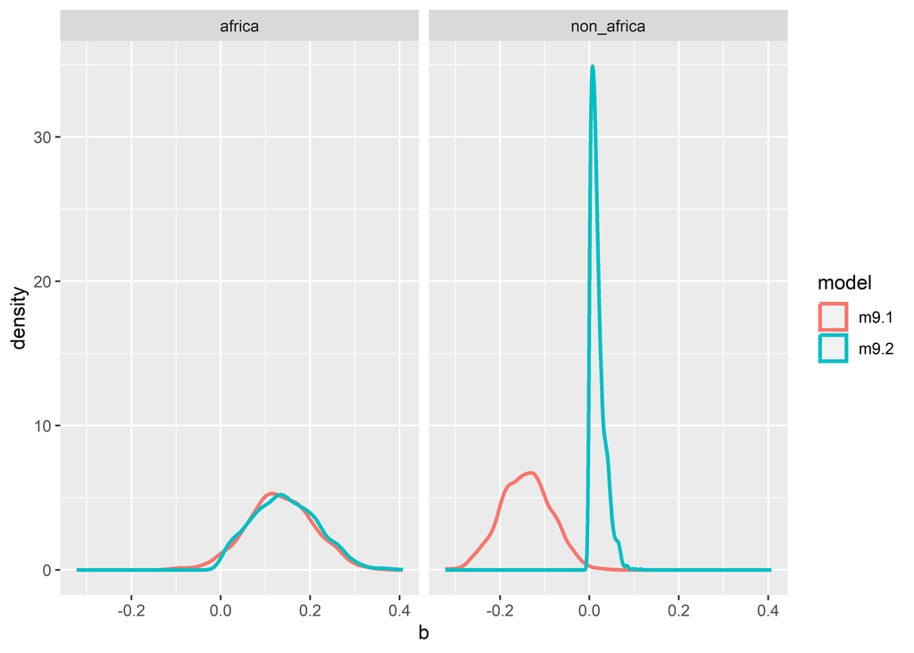

```r
post_b %>%
  ggplot(aes(x = b,  color = model)) +
  geom_density(size = 1)+
  facet_wrap(vars(continent))
```

And, should not the the Rhat be 1? Well, they are close to 1. And the n_eff is below the number of iterations = 1000. The estimation of the model m9.2 did produce a warning message about divergence.

```r
precis(m9.2, depth = 2)
```

```
            mean          sd        5.5%      94.5%    n_eff    Rhat4
a[1]  0.88705202 0.015426207 0.863470534 0.91124579 266.4098 1.005743
a[2]  1.04838493 0.009700997 1.033206611 1.06441663 167.4733 1.038833
b[1]  0.14425273 0.072842657 0.029206305 0.26426489 186.8420 1.030909
b[2]  0.01837194 0.016021674 0.001039468 0.04913501 176.4087 1.023509
sigma 0.11370049 0.006204786 0.104185771 0.12433771 179.5118 1.013731
```

Traceplot. Try to look at the chains. The estimation of beta_africa looks wild, like it is not converging.

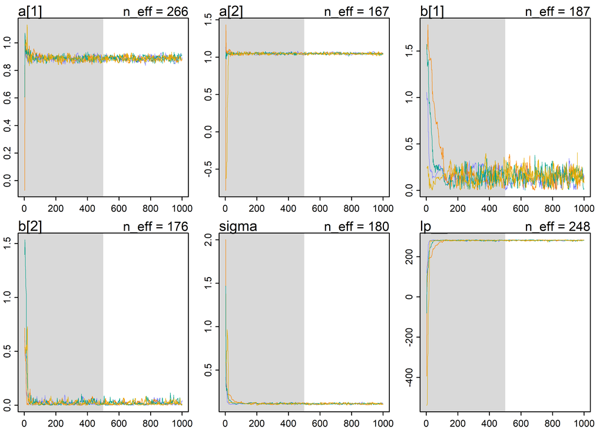

```r
par(mfrow=c(1,1))

tracerplot(object= m9.2) # I could not make traceplot() work.
```

Based on this trankplot (m9.2) and how well mixed the previous m9.1 was, a[1] and b[2] seem to be less mixed. Though, it is hard to tell, as the mixing was not the worst.

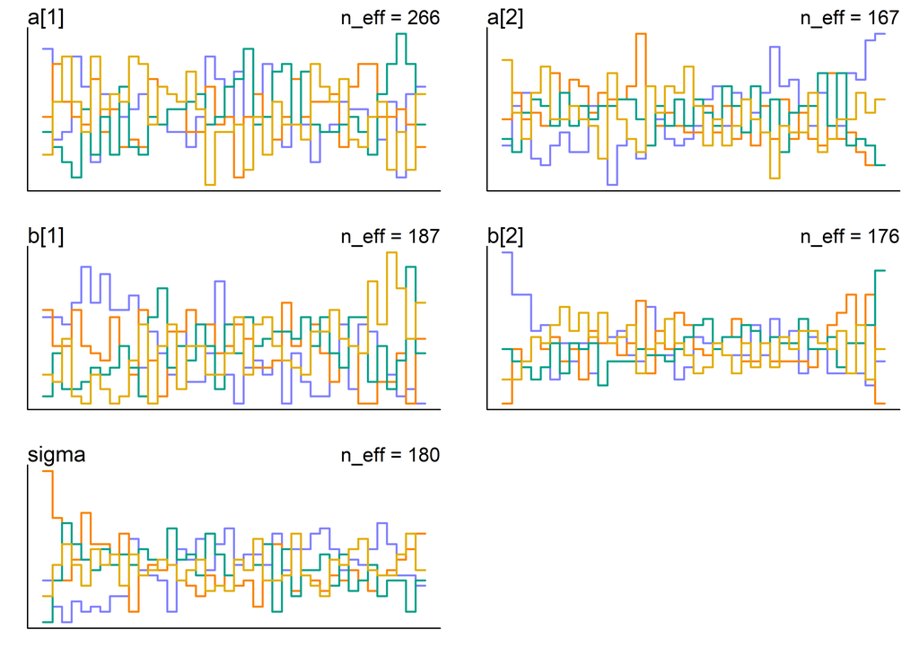

```r
trankplot(m9.2, n_cols = 2)
```

## 9M3. Change warmup iterations

**Re-estimate one of the Stan models from the chapter, but at different numbers of warmup iterations. Be sure to use the same number of sampling iterations in each case. Compare the n_eff values. How much warmup is enough?**

```r
# set iterations to 50 to reduce running time, just for the sake of this exercise


m9.1_wp_250 <- map2stan(
  alist(
    log_gdp_std ~ dnorm( mu , sigma ) ,
    mu <- a[cid] + b[cid]*( rugged_std - 0.215 ) ,
    a[cid] ~ dnorm( 1 , 0.1 ) ,
    b[cid] ~ dnorm( 0 , 0.3 ) ,
    sigma ~ dexp( 1 )
    ),
  data=dat_slim , chains=4 , cores=4 , iter=500, warmup = 250
  )
```

```
Computing WAIC
```

```r
m9.1_wp_150 <- map2stan(
  alist(
    log_gdp_std ~ dnorm( mu , sigma ) ,
    mu <- a[cid] + b[cid]*( rugged_std - 0.215 ) ,
    a[cid] ~ dnorm( 1 , 0.1 ) ,
    b[cid] ~ dnorm( 0 , 0.3 ) ,
    sigma ~ dexp( 1 )
    ),
  data=dat_slim , chains=4 , cores=4 , iter=500, warmup = 150
  )
```

```
Computing WAIC
```

```r
m9.1_wp_50 <- map2stan(
  alist(
    log_gdp_std ~ dnorm( mu , sigma ) ,
    mu <- a[cid] + b[cid]*( rugged_std - 0.215 ) ,
    a[cid] ~ dnorm( 1 , 0.1 ) ,
    b[cid] ~ dnorm( 0 , 0.3 ) ,
    sigma ~ dexp( 1 )
    ),
  data=dat_slim , chains=4 , cores=4 , iter=500, warmup = 50
  )
```

```
Computing WAIC
```

```r
m9.1_wp_10 <- map2stan(
  alist(
    log_gdp_std ~ dnorm( mu , sigma ) ,
    mu <- a[cid] + b[cid]*( rugged_std - 0.215 ) ,
    a[cid] ~ dnorm( 1 , 0.1 ) ,
    b[cid] ~ dnorm( 0 , 0.3 ) ,
    sigma ~ dexp( 1 )
    ),
  data=dat_slim , chains=4 , cores=4 , iter=500, warmup = 10
  )
```

```
Computing WAIC
```

For the models having 50% warmup, 30% and 10% the Rhat is 1 and n_eff is larger than the number of iterations (500). It is a problem estimating for the fourth model having only 2% warmup.

```r
precis(m9.1_wp_250, depth = 2)
```

```
            mean          sd         5.5%       94.5%    n_eff     Rhat4
a[1]   0.8866080 0.016628765  0.861624793  0.91303121 1399.242 0.9979724
a[2]   1.0505996 0.009745050  1.034794758  1.06614350 1728.920 0.9976957
b[1]   0.1305116 0.073522999  0.008522143  0.24781690 1274.541 0.9976528
b[2]  -0.1441022 0.054037319 -0.229949453 -0.05917468 1215.039 0.9997134
sigma  0.1114555 0.006101438  0.102077692  0.12181284 1108.225 0.9970238
```

```r
precis(m9.1_wp_150, depth = 2)
```

```
            mean          sd         5.5%       94.5%     n_eff     Rhat4
a[1]   0.8867856 0.015501756  0.862338648  0.91135609 1907.1341 0.9983714
a[2]   1.0509767 0.009764664  1.035312458  1.06642036 2384.7848 0.9984558
b[1]   0.1309160 0.075221290  0.003648506  0.25119818  854.8944 0.9998727
b[2]  -0.1430814 0.057798672 -0.233939509 -0.04893547  800.1169 1.0015531
sigma  0.1109470 0.006004444  0.102088270  0.12109365  643.2546 1.0024720
```

```r
precis(m9.1_wp_50, depth = 2)
```

```
            mean          sd         5.5%       94.5%     n_eff     Rhat4
a[1]   0.8867483 0.016161463  0.861969668  0.91351720 2094.0517 0.9982837
a[2]   1.0505325 0.010165304  1.034185364  1.06615470 2206.7642 1.0010616
b[1]   0.1304075 0.075346606  0.009747165  0.24684522  747.4310 1.0018582
b[2]  -0.1413388 0.056017684 -0.229653072 -0.05237504 1037.8245 1.0012011
sigma  0.1117507 0.006248777  0.102146531  0.12233880  861.7708 1.0003887
```

Finally, a clear problem. This model that have 10 samples for warmup out of 500 samples, have n_eff smaller than 500 and Rhat above 1.

```r
precis(m9.1_wp_10, depth = 2)
```

```
            mean         sd         5.5%       94.5%    n_eff    Rhat4
a[1]   0.8807930 0.08998977  0.858048272  0.91209180 344.1895 1.008763
a[2]   1.0471727 0.06750128  1.033184835  1.06621395 469.1979 1.006774
b[1]   0.1204172 0.14626093 -0.005624563  0.26670604 160.6764 1.017384
b[2]  -0.1321307 0.16485192 -0.238712313 -0.04728916 146.5958 1.022767
sigma  0.1169623 0.05417848  0.101673481  0.12429780 198.2280 1.014794
```